# Specification of Reference Case Operating Model for Peruvian Anchoveta

### Size Limit Implementation

#### Sampled Parameters

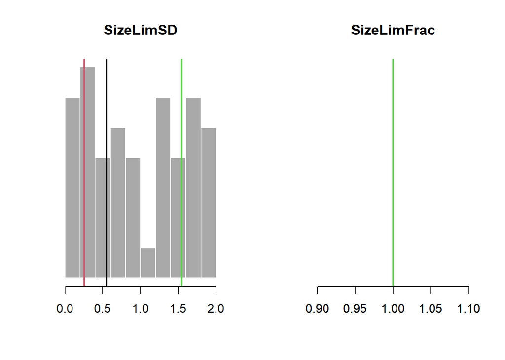

#### Time-Series

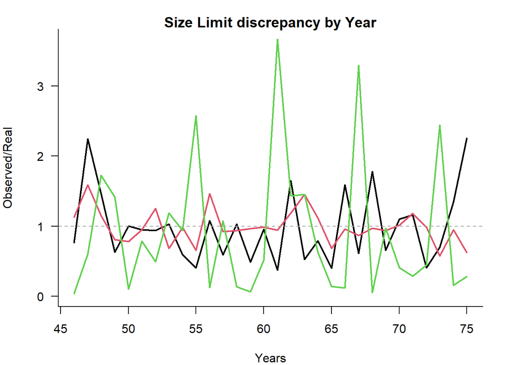

# Historical Simulation Plots

## Historical Time-Series

### Spawning Biomass

#### Depletion

Time-series plots of SB/SB0:

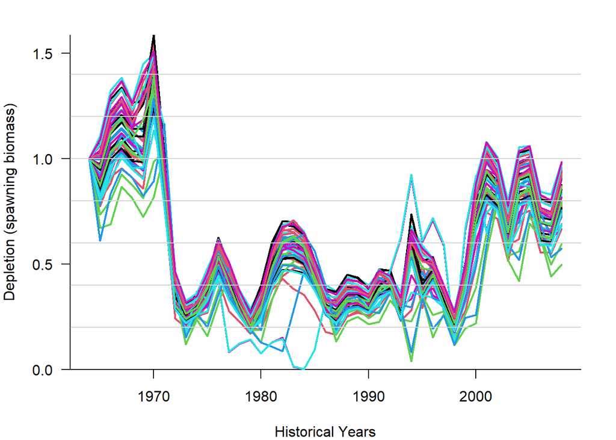

#### Absolute

Time-series plots of absolute SB:

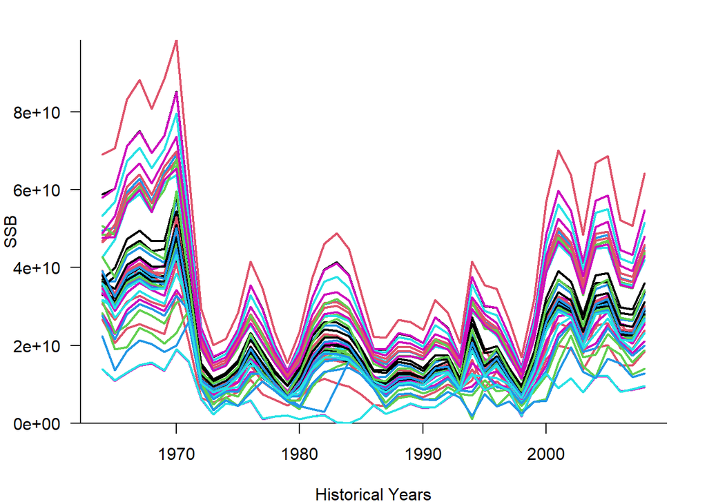

### Vulnerable Biomass

#### Depletion

Time-series plots of VB/VB0:

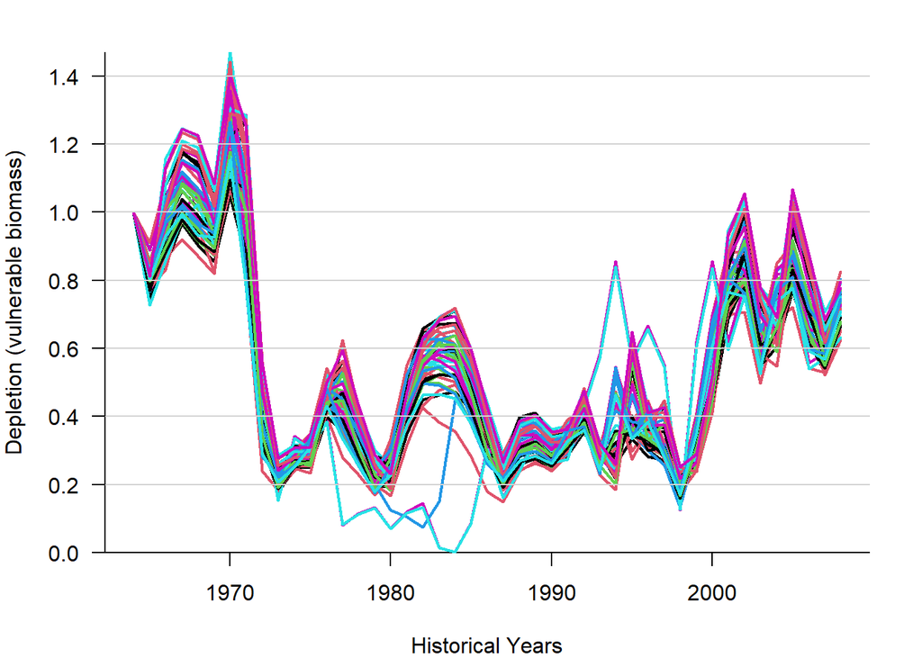

#### Absolute

Time-series plots of absolute VB:

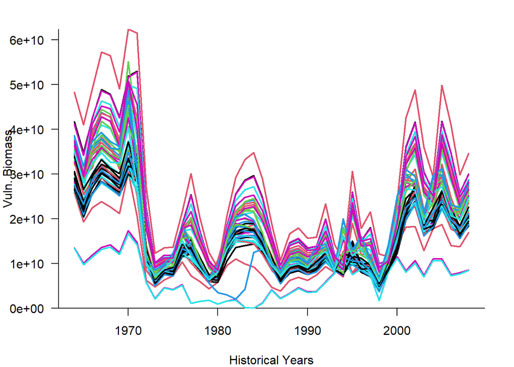

### Total Biomass

#### Depletion

Time-series plots of B/B0:

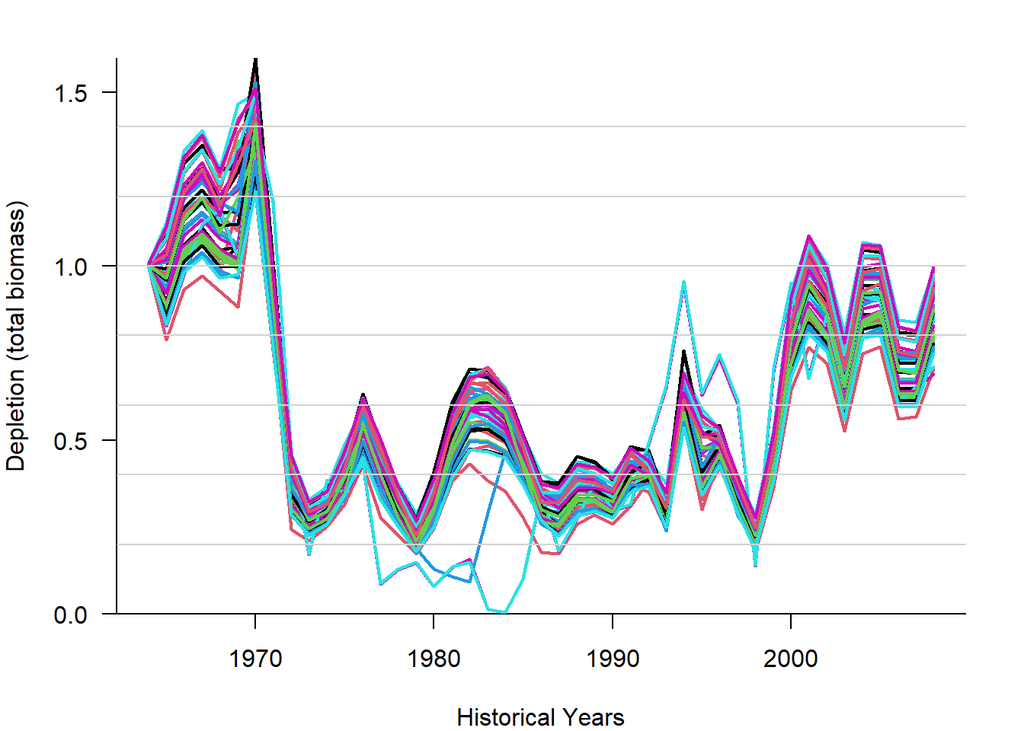

#### Absolute

Time-series plots of absolute B:

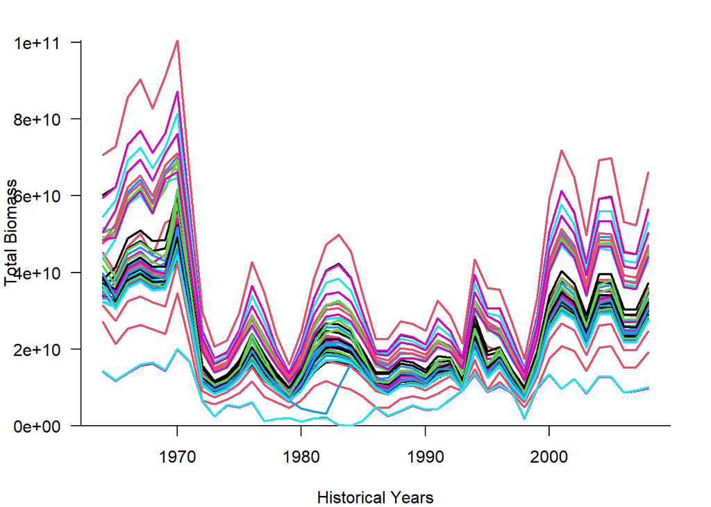

### Recruitment

#### Relative

Time-series plot of recruitment relative to R0:

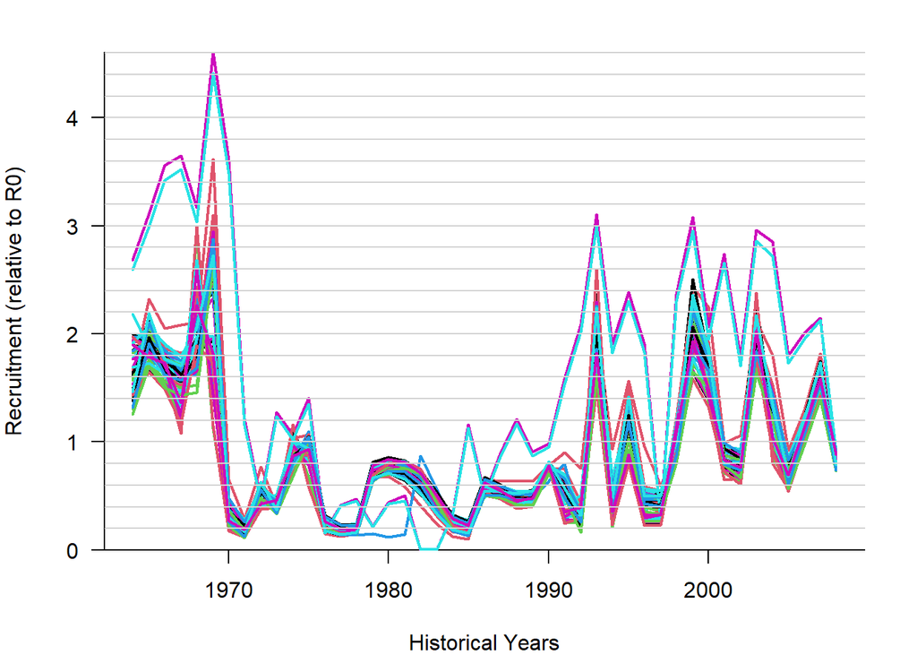

#### Absolute

Time-series plot of absolute recruitment:

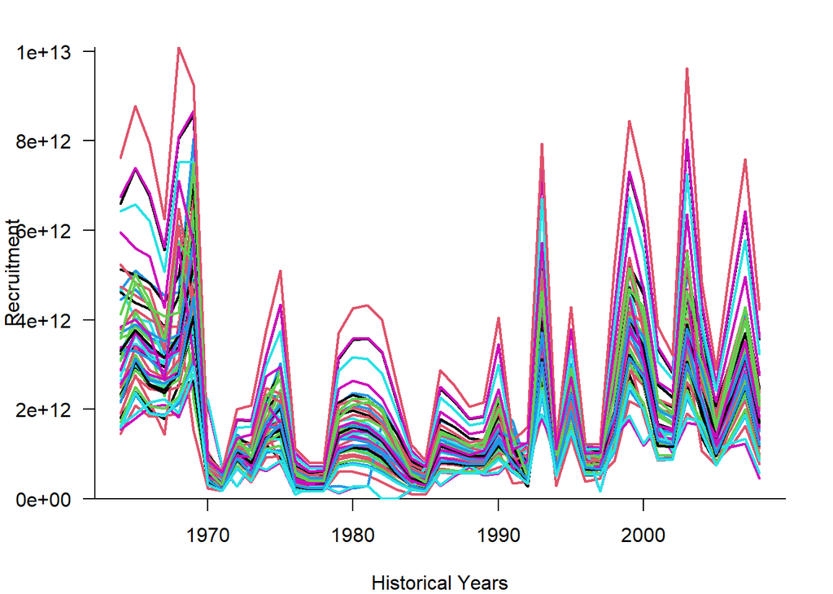

### Catch

#### Relative

Time-series of catch relative to the current year:

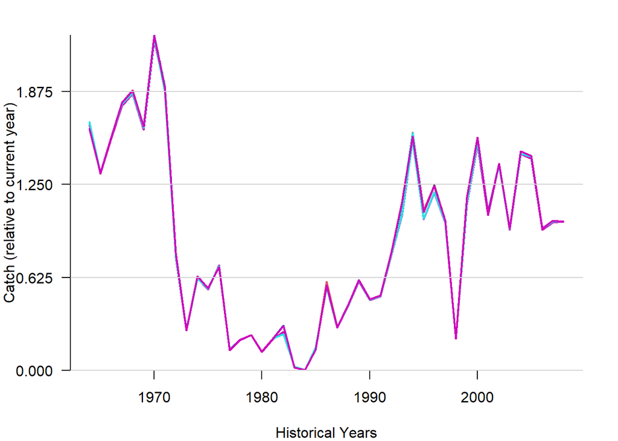

#### Absolute

Time-series of absolute catch:

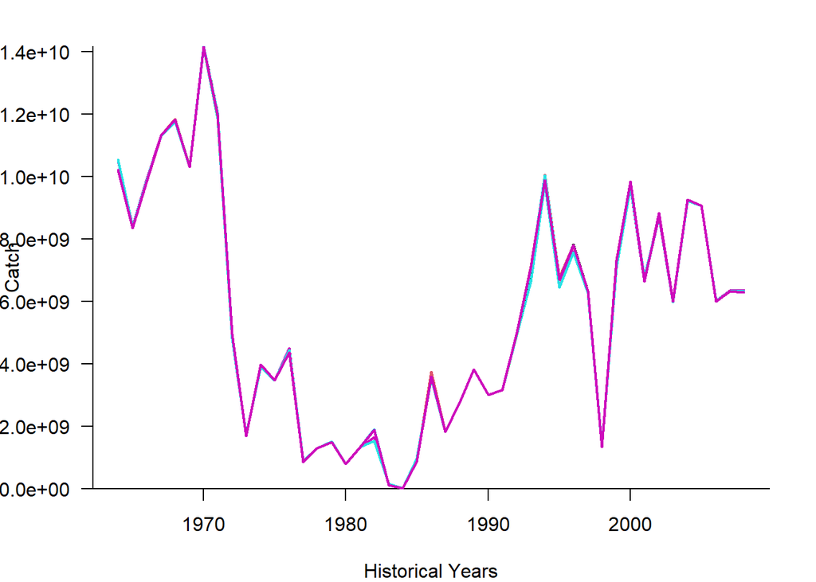

### Historical Fishing Mortality

#### Historical Time-Series

Time-series of historical fishing mortality:

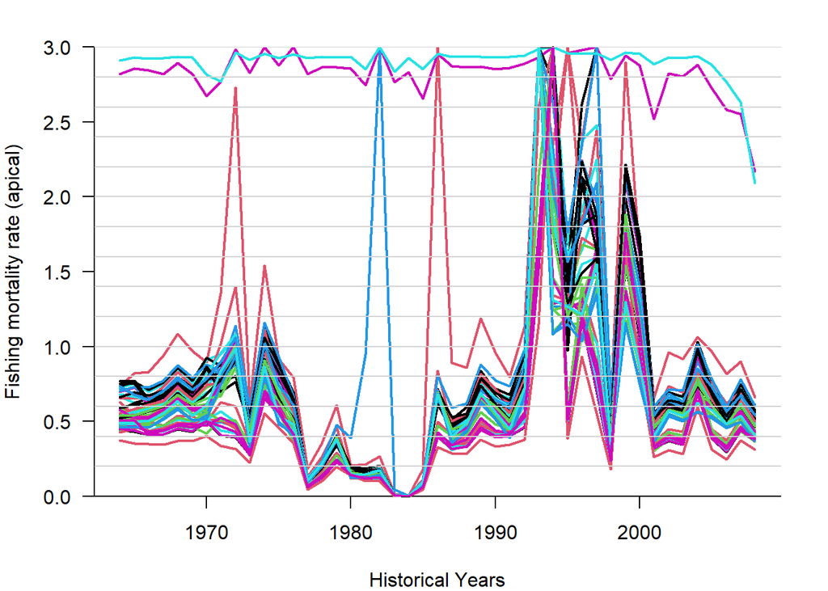

# References

Cardenas, M.P. 2015. Length, weight and proximal chemical composition of Peruvian anchovy in the year 2003-2004. DOI: 10.13140/RG.2.1.2774.0881

CEDAPESCA. 2021. Peruvian Anchovy (Indirect Human Consumption). Available from: https://cedepesca.net/proyectos/peruvian-anchovy-indirect-human-consumption/

Gutiérrez M. 2000. Estimados de biomasa hidroacústica de los cuatro principales recursos pelágicos en el mar peruano durante 1983 -2000. Bol. Inst. Mar Perú. 19(1-2): 136-156.

IMARPE. 2010. Informe sobre la quinta reunión de expertos en dinámica de población de la anchoveta peruana. Bol. Inst. Mar.Perú.

Jordán R. 1976. Biología de la anchoveta. Parte I: Resumen del conocimiento actual. FAO Tech. Rep. 185: 359–399.

Niquen, M. & Bouchon, M. 2004. Impact of El Nino events on pelagic fisheries in Peruvian waters. Deep Sea Research Part II: Topical Studies in Oceanography. 51 (609), 563-574. Doi: 10.1016/j.dsr2.2004.03.001

Oliveros-Ramos, R., Guevar-Carrasco, R., Simmonds, J., Csirke, J., Gerlotto, F., Pena, C., Tam, J. 2010. Modelo de evaluacion integrada del stock norte-centro de la anchoveta peruana Engraulis ringens Jenyns. Bol. Inst. Mar. Peru. 25(1): 49-55.

Palomares ML, Muck P, Mendo J, Chuman E, Gómez O, Pauly D. 1987. Growth of the Peruvian anchoveta (Engraulis ringens), 1953 to 1982. In: Pauly D, Tsukayama I (eds.), The Peruvian Anchoveta and its Upwelling Ecosystem: Three Decades of Change. ICLARM Studies and Reviews 15, pp. 117–141.

Perea, A., Pena, C., Oliveros-Ramos, R., Buitron, B. 2011. Potential egg production, recruitment, and closed fishing season of the Peruvian anchovy (Engraulis ringens): Implications for fisheries management. Ciencias Marinas. 37(4B): 585-601. DOI: 10.7773/cm.v37i4B.1827